# Risk Factor Analysis

## Outcome Variable

**Outcome Variable:** ever_stunted

## Predictor Variables

**Intervention Variable:** tr

**Adjustment Set:**

unadjusted

## Stratifying Variables

The analysis was stratified on these variable(s):

- perdiar6
- agecat
- studyid
- country

## Data Summary

| perdiar6 | agecat | studyid | country | tr | ever_stunted | n_cell | n |
| --- | --- | --- | --- | --- | --- | --- | --- |
| Q1 | 0-6 months | ki1017093b-PROVIDE | BANGLADESH | Control | 0 | 138 | 635 |
| Q1 | 0-6 months | ki1017093b-PROVIDE | BANGLADESH | Control | 1 | 23 | 635 |
| Q1 | 0-6 months | ki1017093b-PROVIDE | BANGLADESH | Other | 0 | 409 | 635 |
| Q1 | 0-6 months | ki1017093b-PROVIDE | BANGLADESH | Other | 1 | 65 | 635 |
| Q2 | 0-6 months | ki1017093b-PROVIDE | BANGLADESH | Control | 0 | 4 | 5 |
| Q2 | 0-6 months | ki1017093b-PROVIDE | BANGLADESH | Control | 1 | 1 | 5 |
| Q1 | 6-24 months | ki1017093b-PROVIDE | BANGLADESH | Control | 0 | 100 | 495 |
| Q1 | 6-24 months | ki1017093b-PROVIDE | BANGLADESH | Control | 1 | 24 | 495 |
| Q1 | 6-24 months | ki1017093b-PROVIDE | BANGLADESH | Other | 0 | 277 | 495 |
| Q1 | 6-24 months | ki1017093b-PROVIDE | BANGLADESH | Other | 1 | 94 | 495 |
| Q2 | 6-24 months | ki1017093b-PROVIDE | BANGLADESH | Control | 0 | 1 | 2 |
| Q2 | 6-24 months | ki1017093b-PROVIDE | BANGLADESH | Control | 1 | 1 | 2 |
| Q1 | 0-24 months | ki1017093b-PROVIDE | BANGLADESH | Control | 0 | 99 | 636 |
| Q1 | 0-24 months | ki1017093b-PROVIDE | BANGLADESH | Control | 1 | 62 | 636 |
| Q1 | 0-24 months | ki1017093b-PROVIDE | BANGLADESH | Other | 0 | 278 | 636 |
| Q1 | 0-24 months | ki1017093b-PROVIDE | BANGLADESH | Other | 1 | 197 | 636 |
| Q2 | 0-24 months | ki1017093b-PROVIDE | BANGLADESH | Control | 0 | 2 | 5 |
| Q2 | 0-24 months | ki1017093b-PROVIDE | BANGLADESH | Control | 1 | 3 | 5 |

The following strata were considered:

- perdiar6: Q1, agecat: 0-24 months, studyid: ki1017093b-PROVIDE, country: BANGLADESH
- perdiar6: Q1, agecat: 0-6 months, studyid: ki1017093b-PROVIDE, country: BANGLADESH
- perdiar6: Q1, agecat: 6-24 months, studyid: ki1017093b-PROVIDE, country: BANGLADESH
- perdiar6: Q2, agecat: 0-24 months, studyid: ki1017093b-PROVIDE, country: BANGLADESH
- perdiar6: Q2, agecat: 0-6 months, studyid: ki1017093b-PROVIDE, country: BANGLADESH
- perdiar6: Q2, agecat: 6-24 months, studyid: ki1017093b-PROVIDE, country: BANGLADESH

### Dropped Strata

Some strata were dropped due to rare outcomes:

- perdiar6: Q2, agecat: 0-6 months, studyid: ki1017093b-PROVIDE, country: BANGLADESH
- perdiar6: Q2, agecat: 6-24 months, studyid: ki1017093b-PROVIDE, country: BANGLADESH
- perdiar6: Q2, agecat: 0-24 months, studyid: ki1017093b-PROVIDE, country: BANGLADESH

## Methods Detail

We’re interested in the causal parameters $E[Y_a]$ for all values of $a \in \mathcal{A}$. These parameters represent the mean outcome if, possibly contrary to fact, we intervened to set all units to have $A=a$. Under the randomization and positivity assumptions, these are identified by the statistical parameters $\psi_a=E_W[E_{Y|A,W}(Y|A=a,W)]$. In addition, we’re interested in the mean of $Y$, $E[Y]$ under no intervention (the observed mean). We will estimate these parameters by using SuperLearner to fit the relevant likelihood factors – $E_{Y|A,W}(Y|A=a,W)$ and $p(A=a|W)$, and then updating our likelihood fit using a joint TMLE.

For unadjusted analyses ($W=\{\}$), initial likelihoods were estimated using Lrnr_glm to estimate the simple $E(Y|A)$ and Lrnr_mean to estimate $p(A)$. For adjusted analyses, a small library containing Lrnr_glmnet, Lrnr_xgboost, and Lrnr_mean was used.

Having estimated these parameters, we will then use the delta method to estimate relative risks and attributable risks relative to a prespecified baseline level of $A$.

# Results Detail

## Results Plots

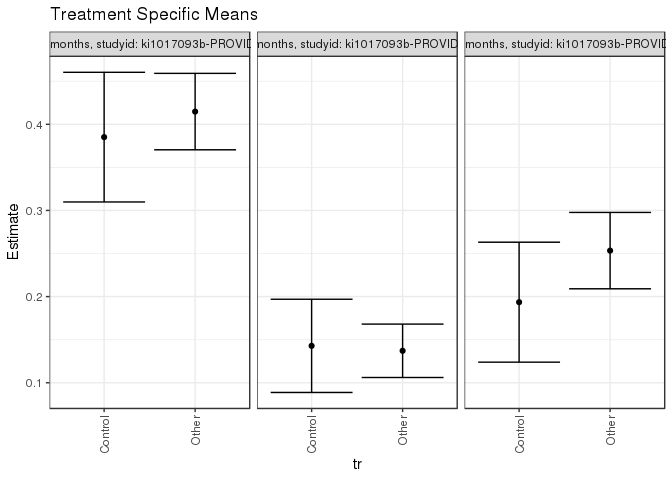

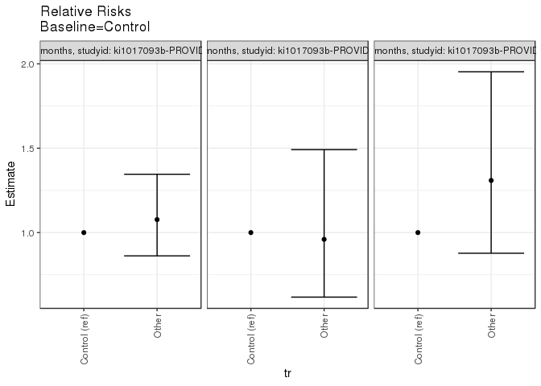

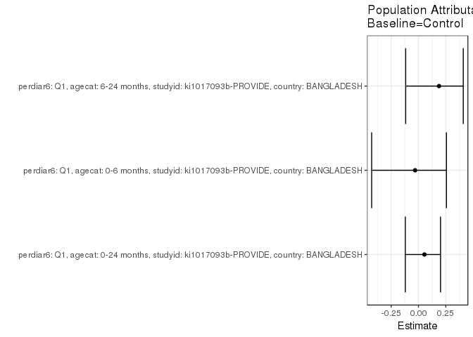

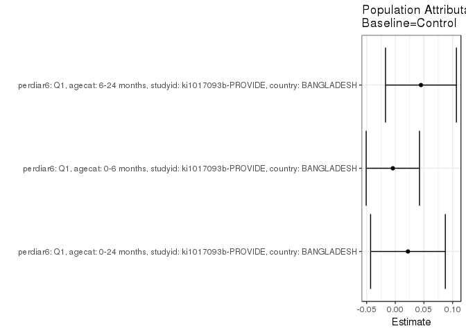

## Results Table

### Parameter: TSM

| perdiar6 | agecat | studyid | country | intervention_level | baseline_level | estimate | ci_lower | ci_upper |
| --- | --- | --- | --- | --- | --- | --- | --- | --- |
| Q1 | 0-24 months | ki1017093b-PROVIDE | BANGLADESH | Control | NA | 0.3850932 | 0.3098678 | 0.4603186 |
| Q1 | 0-24 months | ki1017093b-PROVIDE | BANGLADESH | Other | NA | 0.4147368 | 0.3703959 | 0.4590778 |
| Q1 | 0-6 months | ki1017093b-PROVIDE | BANGLADESH | Control | NA | 0.1428571 | 0.0887624 | 0.1969519 |
| Q1 | 0-6 months | ki1017093b-PROVIDE | BANGLADESH | Other | NA | 0.1371308 | 0.1061394 | 0.1681222 |
| Q1 | 6-24 months | ki1017093b-PROVIDE | BANGLADESH | Control | NA | 0.1935484 | 0.1239402 | 0.2631566 |
| Q1 | 6-24 months | ki1017093b-PROVIDE | BANGLADESH | Other | NA | 0.2533693 | 0.2090666 | 0.2976720 |

### Parameter: E(Y)

| perdiar6 | agecat | studyid | country | intervention_level | baseline_level | estimate | ci_lower | ci_upper |
| --- | --- | --- | --- | --- | --- | --- | --- | --- |
| Q1 | 0-24 months | ki1017093b-PROVIDE | BANGLADESH | NA | NA | 0.4072327 | 0.3690185 | 0.4454469 |
| Q1 | 0-6 months | ki1017093b-PROVIDE | BANGLADESH | NA | NA | 0.1385827 | 0.1116881 | 0.1654773 |
| Q1 | 6-24 months | ki1017093b-PROVIDE | BANGLADESH | NA | NA | 0.2383838 | 0.2008095 | 0.2759582 |

### Parameter: RR

| perdiar6 | agecat | studyid | country | intervention_level | baseline_level | estimate | ci_lower | ci_upper |
| --- | --- | --- | --- | --- | --- | --- | --- | --- |
| Q1 | 0-24 months | ki1017093b-PROVIDE | BANGLADESH | Control | Control | 1.0000000 | 1.0000000 | 1.000000 |
| Q1 | 0-24 months | ki1017093b-PROVIDE | BANGLADESH | Other | Control | 1.0769779 | 0.8619758 | 1.345608 |
| Q1 | 0-6 months | ki1017093b-PROVIDE | BANGLADESH | Control | Control | 1.0000000 | 1.0000000 | 1.000000 |
| Q1 | 0-6 months | ki1017093b-PROVIDE | BANGLADESH | Other | Control | 0.9599156 | 0.6176166 | 1.491926 |
| Q1 | 6-24 months | ki1017093b-PROVIDE | BANGLADESH | Control | Control | 1.0000000 | 1.0000000 | 1.000000 |
| Q1 | 6-24 months | ki1017093b-PROVIDE | BANGLADESH | Other | Control | 1.3090746 | 0.8775904 | 1.952706 |

### Parameter: PAR

| perdiar6 | agecat | studyid | country | intervention_level | baseline_level | estimate | ci_lower | ci_upper |
| --- | --- | --- | --- | --- | --- | --- | --- | --- |
| Q1 | 0-24 months | ki1017093b-PROVIDE | BANGLADESH | Control | NA | 0.0221395 | -0.0430844 | 0.0873635 |
| Q1 | 0-6 months | ki1017093b-PROVIDE | BANGLADESH | Control | NA | -0.0042745 | -0.0508116 | 0.0422626 |
| Q1 | 6-24 months | ki1017093b-PROVIDE | BANGLADESH | Control | NA | 0.0448355 | -0.0170482 | 0.1067191 |

### Parameter: PAF

| perdiar6 | agecat | studyid | country | intervention_level | baseline_level | estimate | ci_lower | ci_upper |
| --- | --- | --- | --- | --- | --- | --- | --- | --- |
| Q1 | 0-24 months | ki1017093b-PROVIDE | BANGLADESH | Control | NA | 0.0543658 | -0.1201898 | 0.2017210 |
| Q1 | 0-6 months | ki1017093b-PROVIDE | BANGLADESH | Control | NA | -0.0308442 | -0.4277548 | 0.2557267 |
| Q1 | 6-24 months | ki1017093b-PROVIDE | BANGLADESH | Control | NA | 0.1880809 | -0.1166696 | 0.4096619 |